# lab2_Adam_Banwell

Adam Banwell

9/17/2021

## installation

```r
library(classdata)
data(choco)
str(choco)
```

```
## Classes 'tbl_df', 'tbl' and 'data.frame':    2452 obs. of  13 variables:
##  $ REF               : num  2454 2458 2454 2542 2546 ...
##  $ Company           : chr  "5150" "5150" "5150" "5150" ...
##  $ Location          : chr  "U.S.A." "U.S.A." "U.S.A." "U.S.A." ...
##  $ ReviewDate        : num  2019 2019 2019 2021 2021 ...
##  $ CountryBeanOrigin : chr  "Tanzania" "Dominican Republic" "Madagascar" "Fiji" ...
##  $ SpecificBeanOrigin: chr  "Kokoa Kamili, batch 1" "Zorzal, batch 1" "Bejofo Estate, batch 1" "Matasawalevu, batch 1" ...
##  $ Ingredients       : chr  "3- B,S,C" "3- B,S,C" "3- B,S,C" "3- B,S,C" ...
##  $ Characteristics1  : chr  "rich cocoa" "cocoa" "cocoa" "chewy" ...
##  $ Characteristics2  : chr  "fatty" "vegetal" "blackberry" "off" ...
##  $ Characteristics3  : chr  "bready" "savory" "full body" "rubbery" ...
##  $ Characteristics4  : chr  NA NA NA NA ...
##  $ Rating            : num  3.25 3.5 3.75 3 3 3.25 3.5 3.5 3.75 2.75 ...
##  $ CocoaPercent      : num  76 76 76 68 72 80 68 70 63 70 ...
```

#Searching for the Best Chocolates

#Question 1

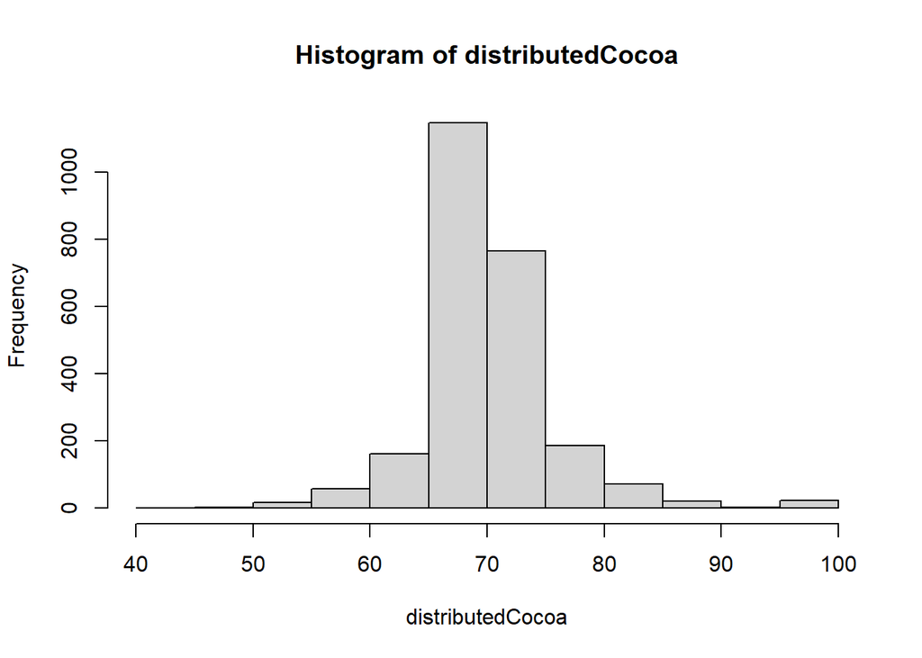

```r
#grab cocoa percent data from Choco data and create histogram/boxplot
distributedCocoa = choco$CocoaPercent
hist(distributedCocoa)
```

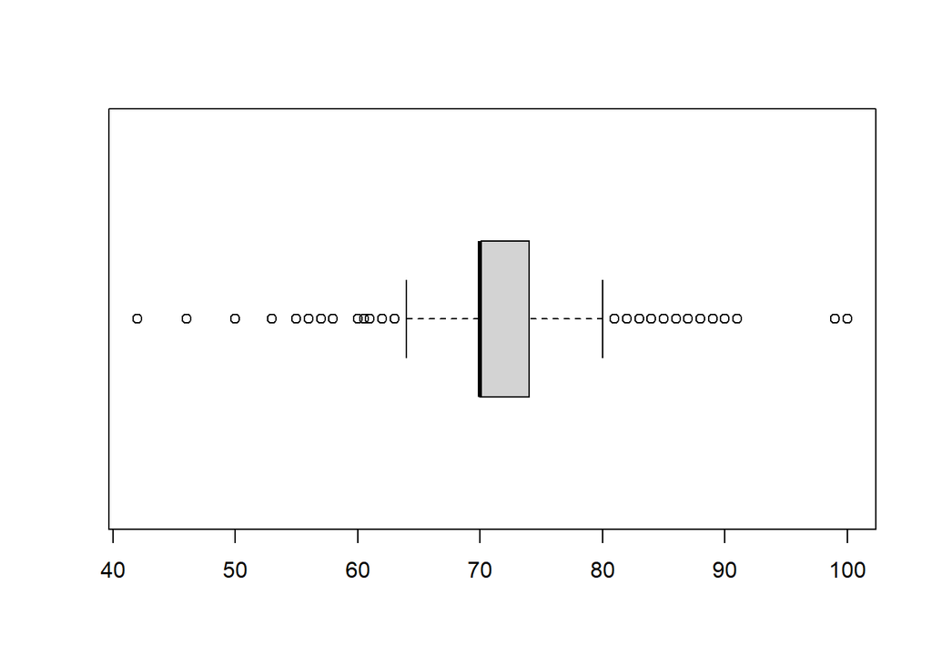

```r
boxplot(distributedCocoa, horizontal = TRUE)
```

For the histogram and box plot above, there are outliers clearly seen outside the whiskers of the box plot.The whiskers start at about 64% and end about 80% so all points below or above those points respectfully are considered outliers.

#Question 2

```r
#install plotting libraries, summarise and group choco data by countrybeanorigin and avgrating
library(dplyr)
library(ggplot2)
ratingsVOrigin = summarise(group_by(choco, CountryBeanOrigin), avgRating = mean(Rating))
ratingsVOrigin
```

```
## # A tibble: 62 x 2
##    CountryBeanOrigin avgRating
##    <chr>                 <dbl>
##  1 Australia              3.25
##  2 Belize                 3.24
##  3 Blend                  3.04
##  4 Bolivia                3.18
##  5 Brazil                 3.26
##  6 Burma                  3
##  7 Cameroon               3.08
##  8 Colombia               3.22
##  9 Congo                  3.32
## 10 Costa Rica             3.15
## # ... with 52 more rows
```

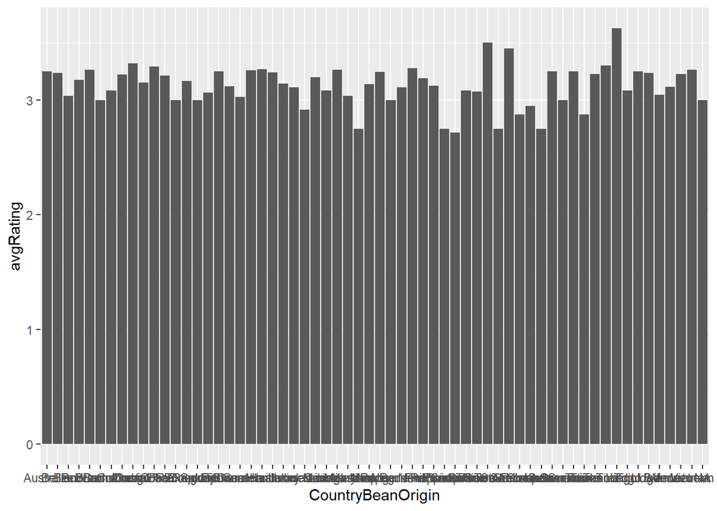

```r
ggplot(ratingsVOrigin, aes(x=CountryBeanOrigin, y=avgRating)) +
    geom_bar(stat='identity')
```

According to the graph, regardless of being too dense, I find it obvious to see that the average rating is around 3 across all countries.

#Question 3

```r
#group percent against rating of cocoa
ratingsVPercent = summarise(group_by(choco, CocoaPercent), avgRating=mean(Rating))
ratingsVPercent
```

```
## # A tibble: 46 x 2
##    CocoaPercent avgRating
##           <dbl>     <dbl>
##  1         42        2.75
##  2         46        2.75
##  3         50        3.75
##  4         53        2
##  5         55        2.86
##  6         56        3.25
##  7         57        2.75
##  8         58        3.12
##  9         60        3.01
## 10         60.5      2.75
## # ... with 36 more rows
```

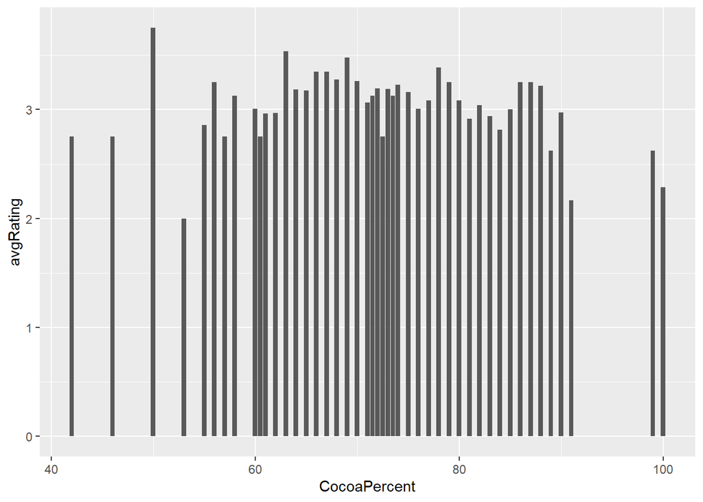

```r
ggplot(ratingsVPercent, aes(x=CocoaPercent, y=avgRating)) +
    geom_bar(stat='identity')
```

Using the numerical and graphical projections above, ratings do not depend on cocoa percent of a chocalate bar. Across all percents the ratings vary.

#Question 4

```r
#group countries vs primary flavors
flavorsVOrigin = summarise(group_by(choco, CountryBeanOrigin), Characteristics1)
flavorsVOrigin
```

```
## # A tibble: 2,452 x 2
## # Groups:   CountryBeanOrigin [62]
##    CountryBeanOrigin Characteristics1
##    <chr>             <chr>
##  1 Australia         vanilla
##  2 Australia         sandy
##  3 Australia         delicate
##  4 Belize            roasty
##  5 Belize            burnt toast
##  6 Belize            floral
##  7 Belize            gritty
##  8 Belize            unbalanced
##  9 Belize            sweet
## 10 Belize            balanced
## # ... with 2,442 more rows
```

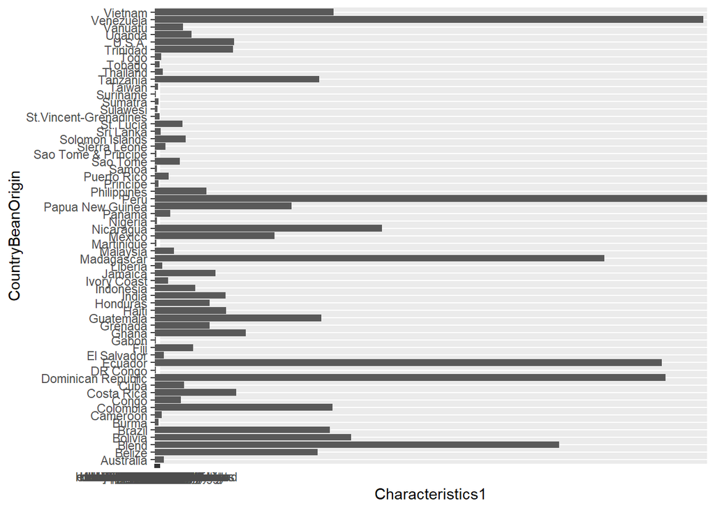

```r
ggplot(na.omit(flavorsVOrigin), aes(x=CountryBeanOrigin, y=Characteristics1)) +
    geom_bar(stat='identity') +
    coord_flip()
```

According to the numerical and graphical projections above, different bean origins will compare largely different in terms of flavors of chocolate. For example, Venezuela, Peru, Madagascar, Ecuador, and Dominican Republic all have a lot wide range of available flavors of chocolate. Using information gained from question 2’s projections, the answer is no, beans from some places are not better than others. Other places will just have more flavors available than some.

#Question 5

1. Comparison of Company to Chocolate Rating, Does Company effect Rating?
2. Comparison of ReviewDate to Chocolate Rating, Does ReviewDate effect Rating?
3. Comparison of SpecificBeanOrigin to Chocolate Rating, Does SpecificBeanOrigin effect Rating?

```r
#group together by comparisons listed above 3 different ways
groupings = summarise(group_by(choco, Company), avgRating=mean(Rating))
groupings
```

```
## # A tibble: 570 x 2
##    Company                       avgRating
##    <chr>                             <dbl>
##  1 5150                               3.32
##  2 A. Morin                           3.4
##  3 Acalli                             3.56
##  4 Adi aka Fijiana (Easy In Ltd)      3.25
##  5 Aelan                              2.75
##  6 Aequare (Gianduja)                 2.88
##  7 Ah Cacao                           3
##  8 Akesson's (Pralus)                 3.08
##  9 Alain Ducasse                      2.83
## 10 Alexandre                          3.5
## # ... with 560 more rows
```

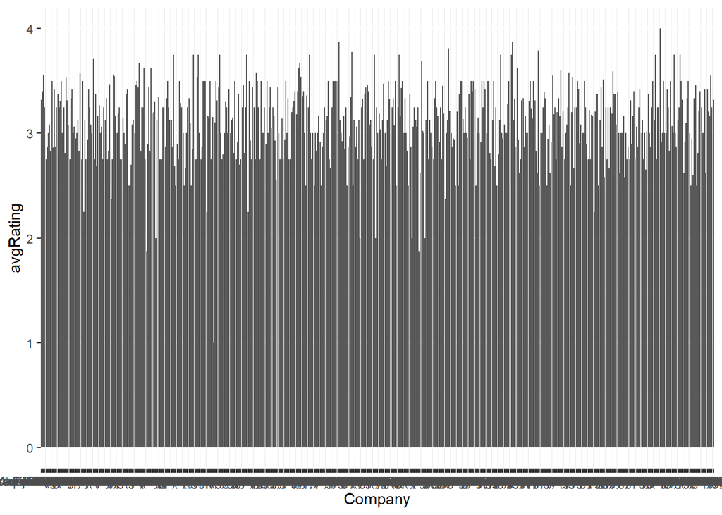

```r
ggplot(groupings, aes(x=Company, y=avgRating)) +
    geom_bar(stat='identity')
```

```r
groupings = summarise(group_by(choco, ReviewDate), avgRating=mean(Rating))
groupings
```

```
## # A tibble: 16 x 2
##    ReviewDate avgRating
##         <dbl>     <dbl>
##  1       2006      3.00
##  2       2007      3.10
##  3       2008      3
##  4       2009      3.07
##  5       2010      3.15
##  6       2011      3.26
##  7       2012      3.18
##  8       2013      3.20
##  9       2014      3.19
## 10       2015      3.24
## 11       2016      3.23
## 12       2017      3.36
## 13       2018      3.19
## 14       2019      3.13
## 15       2020      3.26
## 16       2021      3.32
```

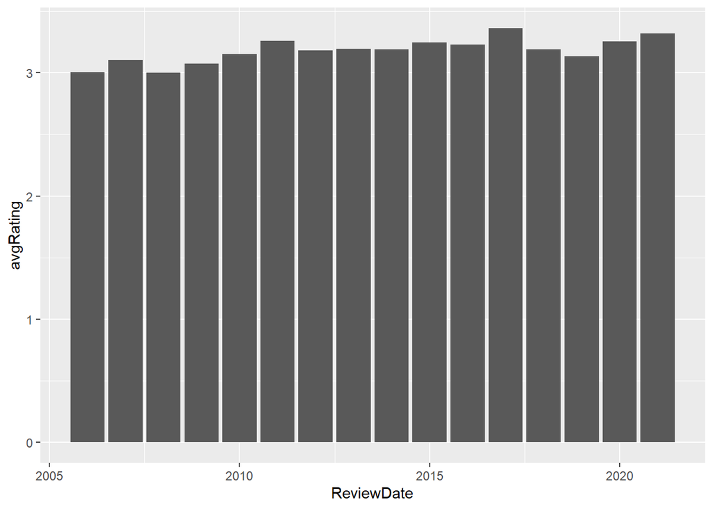

```r
ggplot(groupings, aes(x=ReviewDate, y=avgRating)) +
    geom_bar(stat='identity')
```

```r
groupings = summarise(group_by(choco, SpecificBeanOrigin), avgRating=mean(Rating))
groupings
```

```
## # A tibble: 1,544 x 2
##    SpecificBeanOrigin                                      avgRating
##    <chr>                                                       <dbl>
##  1 "\"Classic Dark\", Ecuador-Guatemala-Dom. Rep."              3.5
##  2 "\"Cocoa Nibs\", Hispaniola w/ nibs"                         3.75
##  3 "\"heirloom\", Arriba Nacional"                              3.5
##  4 "\"Peace of Wild Things\""                                   3
##  5 "\"Roasted Cocoa Nibs\", Latin America Blend, b.060321"      3
##  6 "100 percent"                                                1.5
##  7 "2009 Hapa Nibby, Dominican Rep., Bali"                      3.75
##  8 "A case of the Xerces Blues, triple roast"                   3.5
##  9 "Abinao, West Africa"                                        2.5
## 10 "ABOCFA Coop"                                                4
## # ... with 1,534 more rows
```

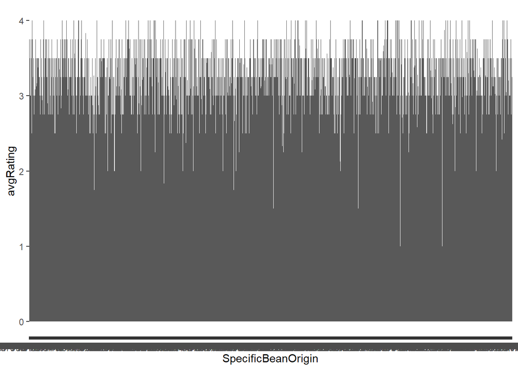

```r
ggplot(groupings, aes(x=SpecificBeanOrigin, y=avgRating)) +
    geom_bar(stat='identity')
```